# Rapport d’enquête PUDT

Frédéric Baudron, François Gatignol, Julie Murel, Lambert Moundzeo

6/12/2024

# 1. Introduction

Ce apport synthétise les principaux résultats d’une enquête de 1422 ménages conduite entre le 23 juillet et le 20 septembre 2024.

Cette enquête visait l’agriculture familiale du COngo et avait pour but de: - Caractériser la diversité des exploitations familiales - Comprendre les interactions agriculture-forêt - Cerner les contraintes et opportunités et estimer les niveaux de production autour de 7 cultures cibles: manioc, mais, soja, arachide, safou, palmier, et plantain.

Les localités (villages) ont été utilisées comme premier degré déchantillonnage, puis dans chaque localité sélectionnées, 10 exploitations ont été sélectionnées de façon aléatoire (deuxième degré d’échantionnage). Dans un premier temps, 100 localités ont été sélectionnées pas échantionnage aléatoire stratifié, en utilisant la végétation comme strate (voire rapport de mission de Boulakia, Baudron, Gatignol et Murel de 2024 pour plus de détails). Cette échantillon a ensuite été complété par d’autres villages représentatifs de la diversité des départements, tel que révélé par les zonages à dire d’acteurs (ZADA). De ce processus est résulté un échantillon représentatif et raisonné de 151 villages.

Nombre de ménages enquêtés par département

| Département | Nombre de ménages |
| --- | --- |
| Bouenza | 191 |
| Cuvette | 102 |
| Cuvette-Ouest | 71 |
| Kouilou | 124 |
| Likouala | 71 |
| Lékoumou | 107 |
| Niari | 255 |
| Plateaux | 200 |
| Pool | 243 |
| Sangha | 58 |

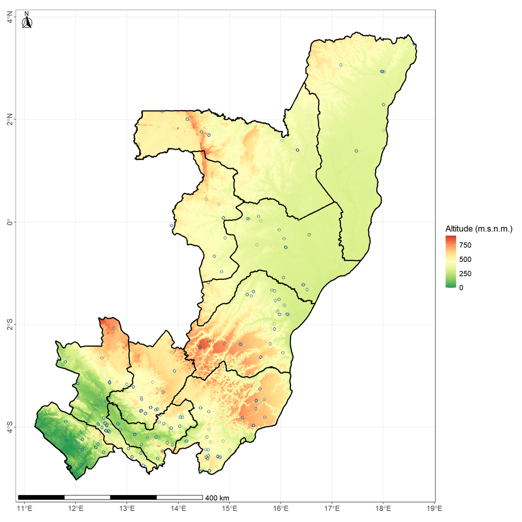

Localisation des ménages enquêtés

# 2. Caractéristiques de l’enquêté et du ménage

Langues parlées par l’enquêté

| **Langue** | **Overall** N = 1,422 | **Bouenza** N = 191 | **Cuvette** N = 102 | **Cuvette-Ouest** N = 71 | **Kouilou** N = 124 | **Lékoumou** N = 107 | **Likouala** N = 71 | **Niari** N = 255 | **Plateaux** N = 200 | **Pool** N = 243 | **Sangha** N = 58 |
| --- | --- | --- | --- | --- | --- | --- | --- | --- | --- | --- | --- |
| lingala | 5.3% | 3.7% | 2.9% | 0% | 0.8% | 13% | 9.9% | 0% | 0% | 17% | 5.2% |
| kikongo | 2.8% | 3.1% | 0% | 0% | 3.2% | 0% | 2.8% | 2.7% | 0% | 8.6% | 0% |
| lari | 11% | 1.0% | 1.0% | 0% | 8.1% | 0.9% | 1.4% | 2.4% | 1.0% | 56% | 3.4% |
| kituba | 11% | 14% | 0% | 0% | 4.0% | 50% | 0% | 13% | 0% | 14% | 0% |
| teke | 18% | 14% | 1.0% | 31% | 6.5% | 24% | 2.8% | 2.4% | 57% | 19% | 5.2% |
| mbochi | 6.8% | 0% | 34% | 1.4% | 0% | 0% | 4.2% | 0% | 27% | 0.8% | 1.7% |
| vili | 1.5% | 0% | 0% | 0% | 18% | 0% | 0% | 0% | 0% | 0% | 0% |
| kuilu | <0.1% | 0% | 0% | 0% | 0% | 0% | 1.4% | 0% | 0% | 0% | 0% |
| lubomo | <0.1% | 0% | 0% | 0% | 0% | 0% | 1.4% | 0% | 0% | 0% | 0% |
| bomitaba | 0.5% | 0% | 0% | 0% | 0% | 0% | 5.6% | 0% | 0% | 0.4% | 3.4% |
| ndjem | 0.8% | 0% | 0% | 0% | 0% | 0% | 0% | 0% | 0% | 0% | 19% |
| yombe | 2.7% | 0% | 0% | 0% | 29% | 0% | 4.2% | 0% | 0% | 0% | 0% |
| francais | 8.2% | 8.4% | 0% | 0% | 0% | 32% | 1.4% | 2.7% | 0% | 24% | 1.7% |
| anglais | <0.1% | 0% | 0% | 0% | 0% | 0% | 0% | 0% | 0% | 0.4% | 0% |
| baaka | <0.1% | 0% | 0% | 0% | 0% | 0% | 0% | 0% | 0% | 0% | 1.7% |

Caractéristiques du chef de famille

| **Variable** | **Overall** N = 1,417 | **Bouenza** N = 191 | **Cuvette** N = 102 | **Cuvette-Ouest** N = 71 | **Kouilou** N = 124 | **Lékoumou** N = 107 | **Likouala** N = 71 | **Niari** N = 255 | **Plateaux** N = 200 | **Pool** N = 238 | **Sangha** N = 58 |
| --- | --- | --- | --- | --- | --- | --- | --- | --- | --- | --- | --- |
| Genre du chef de ménage |  |  |  |  |  |  |  |  |  |  |  |
| Femme | 37% | 29% | 63% | 41% | 47% | 20% | 45% | 31% | 37% | 37% | 36% |
| Homme | 63% | 71% | 37% | 59% | 53% | 80% | 55% | 69% | 63% | 63% | 64% |
| Age du chef de ménage | 48.9 (12.8) | 50.0 (13.4) | 46.5 (13.3) | 42.5 (12.5) | 49.0 (13.5) | 49.9 (10.8) | 47.6 (11.3) | 50.7 (12.1) | 47.6 (14.4) | 50.2 (12.4) | 48.0 (8.9) |
| Niveau d’éducation du chef de ménage |  |  |  |  |  |  |  |  |  |  |  |
| Aucun | 12% | 10% | 3.9% | 1.4% | 12% | 9.3% | 44% | 9.0% | 8.5% | 7.1% | 47% |
| Education primaire | 28% | 27% | 29% | 34% | 40% | 27% | 17% | 27% | 29% | 26% | 22% |
| Collège | 45% | 45% | 55% | 56% | 35% | 48% | 32% | 43% | 47% | 54% | 22% |
| Lycée | 12% | 12% | 5.9% | 4.2% | 9.7% | 13% | 7.0% | 18% | 13% | 11% | 6.9% |
| Enseignement supérieur | 3.5% | 6.3% | 5.9% | 4.2% | 2.4% | 2.8% | 0% | 3.1% | 3.5% | 2.9% | 1.7% |
| Originaire du village | 70% | 85% | 73% | 76% | 49% | 92% | 41% | 71% | 64% | 71% | 62% |

Raisons pour lesquelles les allochtones ont quitté leur village

| **Raison** | **Overall** N = 1,422 | **Bouenza** N = 191 | **Cuvette** N = 102 | **Cuvette-Ouest** N = 71 | **Kouilou** N = 124 | **Lékoumou** N = 107 | **Likouala** N = 71 | **Niari** N = 255 | **Plateaux** N = 200 | **Pool** N = 243 | **Sangha** N = 58 |
| --- | --- | --- | --- | --- | --- | --- | --- | --- | --- | --- | --- |
| Insécurité | 5.1% | 8.2% | 0% | 0% | 0% | NA% | 0% | 0% | 0% | 13% | 0% |
| Etudes hors du village | 26% | 24% | 27% | 13% | 0% | NA% | 25% | 60% | 54% | 3.6% | 29% |
| Travail hors du village | 20% | 14% | 27% | 44% | 20% | NA% | 25% | 33% | 13% | 13% | 57% |
| Raisons familiales | 33% | 33% | 41% | 63% | 40% | NA% | 50% | 6.7% | 21% | 38% | 14% |
| Raisons économiques | 23% | 33% | 9.1% | 0% | 40% | NA% | 0% | 27% | 13% | 38% | 0% |
| Autre | 5.1% | 6.1% | 9.1% | 6.3% | 40% | NA% | 13% | 0% | 0% | 3.6% | 0% |

Principales raisons pour laquelle les allochtones ont décidé de s’installer dans le village dans lequel ils habitent actuellement

| **Raison** | **Overall** N = 1,422 | **Bouenza** N = 191 | **Cuvette** N = 102 | **Cuvette-Ouest** N = 71 | **Kouilou** N = 124 | **Lékoumou** N = 107 | **Likouala** N = 71 | **Niari** N = 255 | **Plateaux** N = 200 | **Pool** N = 243 | **Sangha** N = 58 |
| --- | --- | --- | --- | --- | --- | --- | --- | --- | --- | --- | --- |
| Terre natale | 5.2% | 3.4% | 7.1% | 18% | 1.6% | 22% | 12% | 0% | 1.4% | 4.4% | 18% |
| Terre plus fertile | 7.1% | 6.9% | 0% | 0% | 7.9% | 11% | 2.4% | 19% | 2.7% | 7.4% | 0% |
| Zone moins enclavée | 2.8% | 0% | 0% | 0% | 4.8% | 0% | 0% | 2.7% | 4.1% | 5.9% | 0% |
| Accès à la terre plus facile | 8.7% | 0% | 3.6% | 0% | 9.5% | 11% | 2.4% | 16% | 4.1% | 19% | 0% |
| Venu pour trouver de l’emploi, et ai pu trouver de la terre | 19% | 14% | 0% | 0% | 27% | 11% | 9.5% | 20% | 23% | 31% | 14% |
| Conflit dans village natal | 9.9% | 6.9% | 0% | 0% | 7.9% | 0% | 33% | 5.4% | 9.6% | 7.4% | 23% |
| Rejoint un proche/un(e) conjoint(e) | 50% | 55% | 61% | 65% | 43% | 67% | 57% | 49% | 56% | 31% | 59% |
| Autre | 16% | 24% | 32% | 24% | 19% | 44% | 9.5% | 22% | 2.7% | 8.8% | 9.1% |

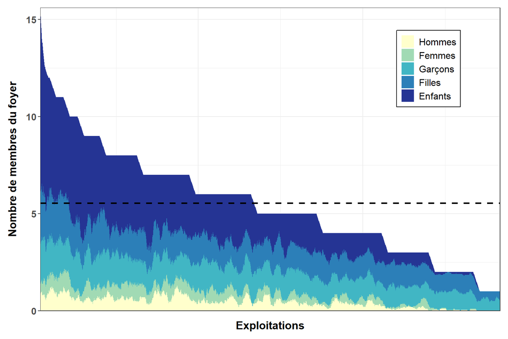

Composition du ménage (les exploitations ont été classées par taille de ménage décroissante, et une moyenne moyenne mobile a été appliquée à des sous-ensembles de 20 exploitations pour lisser les courbes et faciliter leur interprétation. La ligne en pointillés représente la taille moyenne du foyer pour l’échantillon total)

Caractéristiques du ménage

| **Variable** | **Overall** N = 1,417 | **Bouenza** N = 191 | **Cuvette** N = 102 | **Cuvette-Ouest** N = 71 | **Kouilou** N = 124 | **Lékoumou** N = 107 | **Likouala** N = 71 | **Niari** N = 255 | **Plateaux** N = 200 | **Pool** N = 238 | **Sangha** N = 58 |
| --- | --- | --- | --- | --- | --- | --- | --- | --- | --- | --- | --- |
| Taille du ménage | 5.5 (2.9) | 5.1 (2.6) | 6.1 (2.9) | 6.4 (2.6) | 4.1 (2.3) | 6.2 (2.8) | 7.1 (3.3) | 5.7 (3.2) | 5.3 (2.7) | 5.1 (2.7) | 7.3 (3.6) |
| Hommes | 0.4 (0.7) | 0.5 (0.8) | 0.6 (0.8) | 0.5 (0.8) | 0.3 (0.6) | 0.3 (0.6) | 0.4 (0.7) | 0.4 (0.7) | 0.5 (0.7) | 0.5 (0.8) | 0.4 (1.0) |
| Femmes | 0.4 (0.7) | 0.5 (0.8) | 0.6 (0.9) | 0.5 (0.7) | 0.3 (0.5) | 0.2 (0.4) | 0.4 (0.7) | 0.3 (0.7) | 0.4 (0.6) | 0.5 (0.7) | 0.3 (0.6) |
| Garçons | 1.2 (0.9) | 1.2 (0.9) | 1.4 (1.0) | 1.5 (1.0) | 1.1 (0.9) | 1.2 (0.7) | 1.0 (0.7) | 1.2 (0.8) | 1.2 (0.7) | 1.2 (1.0) | 1.4 (1.0) |
| Filles | 1.3 (0.9) | 1.4 (0.9) | 1.4 (0.8) | 1.4 (0.8) | 1.2 (0.8) | 0.8 (0.9) | 1.5 (1.3) | 1.1 (0.9) | 1.2 (0.6) | 1.5 (1.1) | 1.3 (0.7) |
| Enfants | 2.2 (2.4) | 1.5 (1.5) | 2.2 (2.0) | 2.5 (1.8) | 1.3 (1.6) | 3.7 (2.7) | 3.8 (2.9) | 2.6 (2.8) | 1.9 (2.0) | 1.5 (1.7) | 3.8 (3.5) |

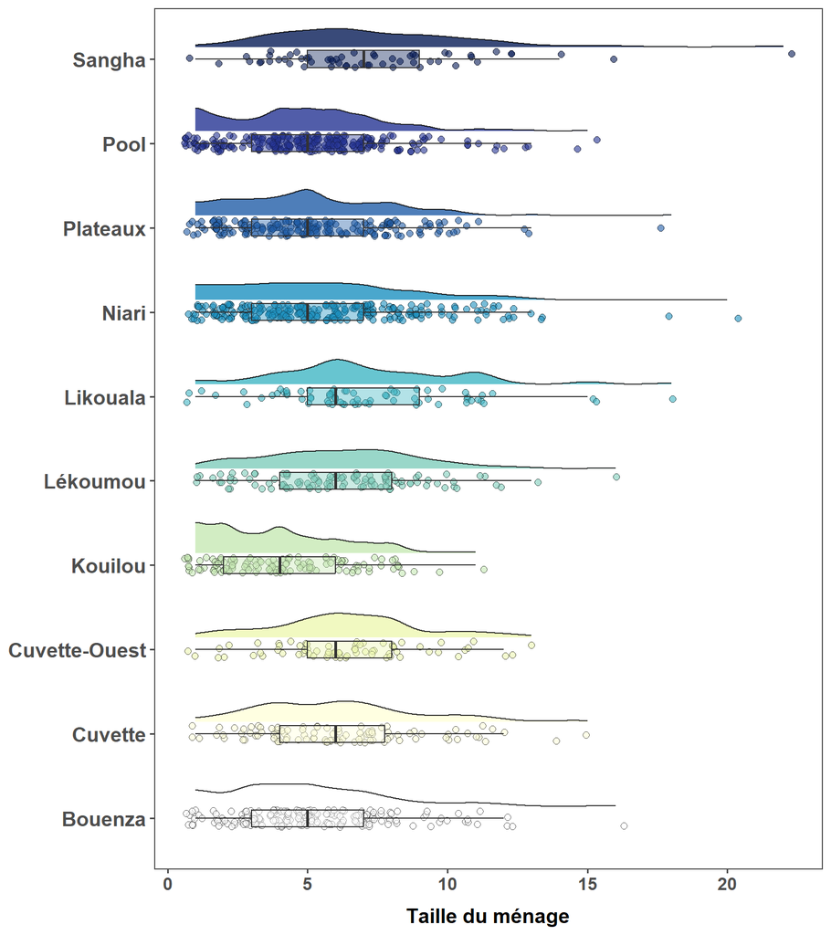

Taille du ménage par département

# 3. Sécurité alimentaire

Sécurité alimentaire

| **Variable** | **Overall** N = 1,422 | **Bouenza** N = 191 | **Cuvette** N = 102 | **Cuvette-Ouest** N = 71 | **Kouilou** N = 124 | **Lékoumou** N = 107 | **Likouala** N = 71 | **Niari** N = 255 | **Plateaux** N = 200 | **Pool** N = 243 | **Sangha** N = 58 |
| --- | --- | --- | --- | --- | --- | --- | --- | --- | --- | --- | --- |
| Nombre moyen de repas par jours |  |  |  |  |  |  |  |  |  |  |  |
| 1 | 3.7% | 8.4% | 0% | 0% | 4.0% | 1.9% | 30% | 1.2% | 0.5% | 0.8% | 3.4% |
| 2 | 70% | 80% | 71% | 68% | 67% | 45% | 68% | 65% | 67% | 86% | 62% |
| 3 ou + | 26% | 12% | 29% | 32% | 29% | 53% | 2.8% | 34% | 33% | 14% | 34% |
| Sécurité alimentaire (pas de nécessité de réduire le nombre de repas) | 31% | 39% | 46% | 55% | 15% | 16% | 5.6% | 28% | 38% | 32% | 22% |

# 4. Agriculture

## 4.1. Général

Structure des exploitations

| **Variable** | **Overall** N = 1,170 | **Bouenza** N = 115 | **Cuvette** N = 92 | **Cuvette-Ouest** N = 69 | **Kouilou** N = 102 | **Lékoumou** N = 106 | **Likouala** N = 61 | **Niari** N = 241 | **Plateaux** N = 148 | **Pool** N = 186 | **Sangha** N = 50 |
| --- | --- | --- | --- | --- | --- | --- | --- | --- | --- | --- | --- |
| Nombre de champs | 2.4 (1.4) | 3.3 (1.5) | 2.5 (1.3) | 3.0 (1.6) | 1.8 (1.1) | 1.8 (0.7) | 2.0 (1.0) | 2.4 (1.4) | 2.8 (1.7) | 2.3 (1.1) | 2.1 (1.0) |
| Nombre de systèmes de culture | 2.0 (1.2) | 2.3 (1.0) | 1.8 (0.8) | 2.0 (1.1) | 1.4 (0.6) | 3.2 (1.8) | 2.1 (0.8) | 1.9 (1.1) | 1.8 (1.1) | 1.8 (0.9) | 2.3 (0.9) |
| Présence d’un jardin | 22% | 23% | 5.4% | 7.2% | 25% | 24% | 23% | 28% | 4.7% | 35% | 22% |
| Présence d’un verger | 38% | 31% | 35% | 49% | 45% | 69% | 25% | 53% | 6.8% | 30% | 24% |
| Terres en jachère | 47% | 57% | 53% | 52% | 34% | 51% | 25% | 42% | 40% | 61% | 50% |
| Terres en location | 18% | 20% | 4.3% | 7.2% | 4.9% | 48% | 3.3% | 19% | 3.4% | 37% | 2.0% |
| Superficie cultivée (ha) | 1.6 (1.3) | 2.1 (1.4) | 1.1 (0.8) | 1.8 (1.0) | 1.3 (1.0) | 1.7 (1.1) | 1.6 (1.0) | 1.6 (1.2) | 1.6 (1.6) | 1.6 (1.4) | 2.1 (1.8) |
| Diversité d’annuelles | 2.8 (1.8) | 3.1 (1.8) | 2.7 (1.5) | 3.6 (1.9) | 1.4 (0.9) | 4.2 (1.9) | 2.0 (0.9) | 2.5 (1.7) | 3.0 (2.0) | 2.7 (1.6) | 1.9 (0.7) |
| Diversité de pérennes | 3.6 (2.4) | 3.2 (2.2) | 4.0 (2.2) | 5.2 (2.1) | 2.9 (2.0) | 4.5 (2.6) | 2.2 (1.8) | 3.6 (2.6) | 3.8 (2.1) | 3.6 (2.3) | 2.8 (1.6) |
| Diversité totale | 6.4 (3.4) | 6.2 (3.3) | 6.7 (2.9) | 8.8 (3.2) | 4.4 (2.3) | 8.7 (3.8) | 4.2 (2.1) | 6.1 (3.7) | 6.9 (3.3) | 6.3 (3.2) | 4.8 (2.1) |
| Orientation vers le marché (vente de plus de 50%) | 61% | 83% | 40% | 48% | 49% | 78% | 30% | 67% | 61% | 64% | 40% |
| Végétation précédente |  |  |  |  |  |  |  |  |  |  |  |
| Forêt dégradée | 46% | 43% | 57% | 68% | 63% | 20% | 34% | 28% | 62% | 59% | 40% |
| Forêt dense / jamais mise en culture | 16% | 5.2% | 29% | 26% | 27% | 10% | 66% | 6.6% | 0.7% | 2.7% | 60% |
| Savane arbustive | 26% | 34% | 11% | 4.3% | 7.8% | 52% | 0% | 40% | 29% | 27% | 0% |
| Savane herbacée | 12% | 17% | 3.3% | 1.4% | 2.0% | 18% | 0% | 25% | 8.1% | 12% | 0% |
| Durée de jachère |  |  |  |  |  |  |  |  |  |  |  |
| 1-2 ans | 9.2% | 7.0% | 5.4% | 0% | 18% | 0% | 9.8% | 23% | 3.4% | 5.4% | 0% |
| 12-15 ans | 6.0% | 5.2% | 8.7% | 17% | 5.9% | 0.9% | 8.2% | 2.1% | 8.8% | 6.5% | 4.0% |
| 15 ans et + | 16% | 6.1% | 35% | 54% | 13% | 0% | 26% | 5.8% | 26% | 8.6% | 32% |
| 3-5 ans | 28% | 32% | 16% | 2.9% | 21% | 75% | 8.2% | 40% | 15% | 26% | 10% |
| 6-8 ans | 10% | 21% | 8.7% | 4.3% | 3.9% | 4.7% | 0% | 5.8% | 7.4% | 27% | 4.0% |
| 9-11 ans | 9.1% | 10% | 4.3% | 13% | 9.8% | 5.7% | 4.9% | 6.2% | 14% | 15% | 2.0% |
| Pas de jachère | 21% | 18% | 22% | 8.7% | 29% | 13% | 43% | 17% | 26% | 12% | 48% |
| Statut foncier des terres cultivées |  |  |  |  |  |  |  |  |  |  |  |
| Autre | 15% | 17% | 8.7% | 13% | 12% | 0.9% | 34% | 12% | 31% | 14% | 14% |
| Location | 10% | 1.7% | 1.1% | 0% | 20% | 0.9% | 13% | 7.9% | 7.4% | 31% | 0% |
| Propriété | 74% | 81% | 90% | 87% | 69% | 98% | 52% | 80% | 61% | 55% | 86% |
| Utilisation de fumier/lisier | 2.6% | 5.2% | 6.5% | 2.9% | 1.0% | 0.9% | 6.6% | 0% | 0% | 5.9% | 0% |
| Utilisation d’engrais minéraux | 1.5% | 0.9% | 2.2% | 0% | 1.0% | 0% | 4.9% | 0% | 0% | 5.9% | 0% |
| Utilisation de pesticides | 1.7% | 4.3% | 0% | 0% | 1.0% | 0% | 0% | 0% | 0% | 7.5% | 0% |

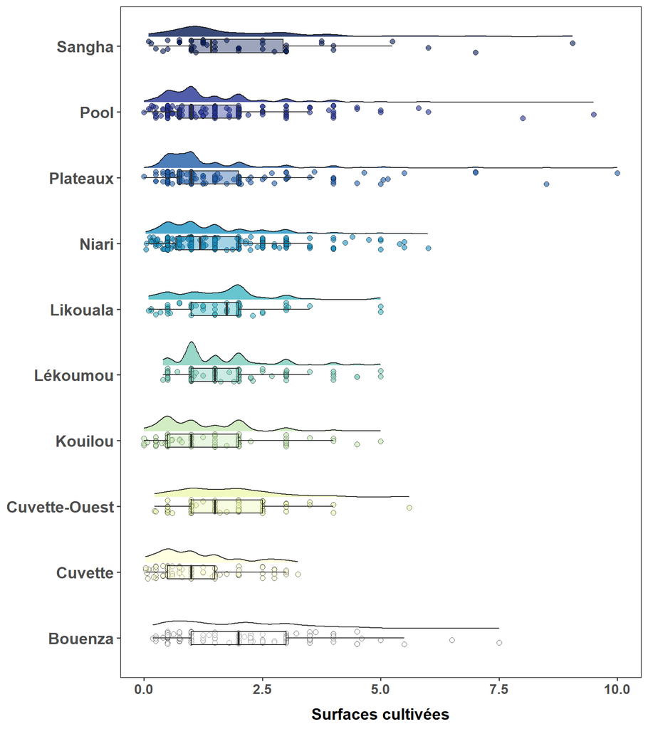

Surfaces cultivées

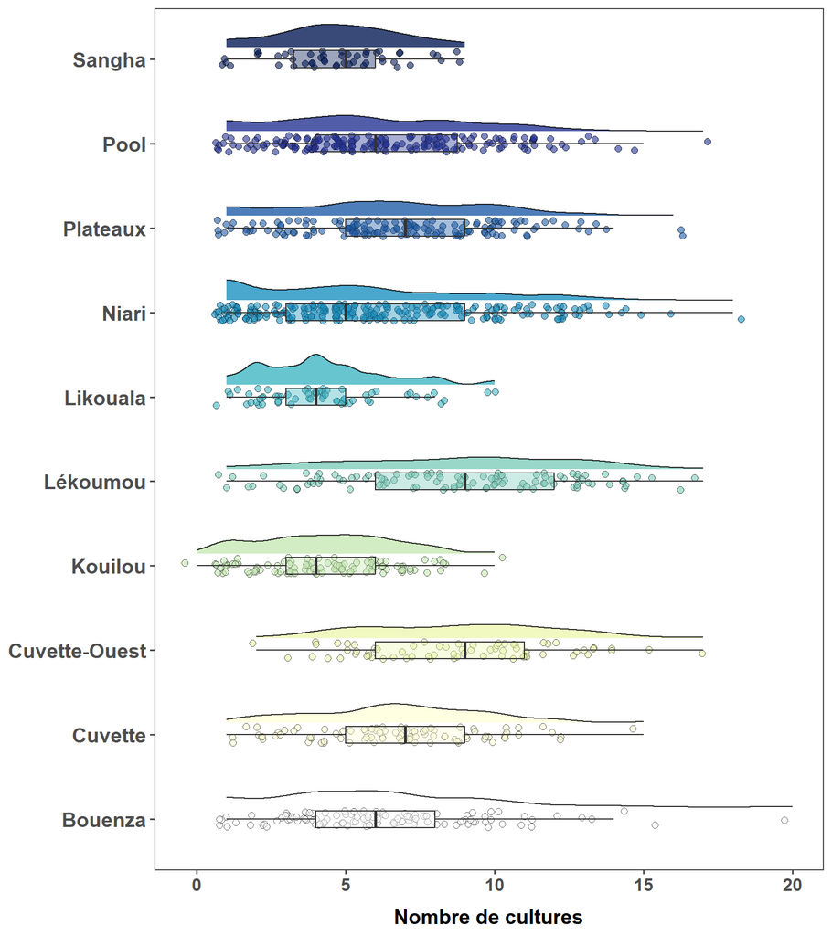

Diversité de cultures annuelles et pérennes

Cultures présentes

| **Variable** | **Overall** N = 1,170 | **Bouenza** N = 115 | **Cuvette** N = 92 | **Cuvette-Ouest** N = 69 | **Kouilou** N = 102 | **Lékoumou** N = 106 | **Likouala** N = 61 | **Niari** N = 241 | **Plateaux** N = 148 | **Pool** N = 186 | **Sangha** N = 50 |
| --- | --- | --- | --- | --- | --- | --- | --- | --- | --- | --- | --- |
| manioc | 98% | 98% | 100% | 97% | 93% | 100% | 100% | 99% | 98% | 98% | 98% |
| maïs | 27% | 16% | 32% | 20% | 2.9% | 53% | 66% | 17% | 26% | 28% | 56% |
| soja | 0.2% | 0% | 0% | 0% | 0% | 0.9% | 0% | 0% | 0.7% | 0% | 0% |
| arachide | 30% | 53% | 6.5% | 0% | 6.9% | 66% | 20% | 36% | 20% | 36% | 26% |
| igname | 13% | 10% | 12% | 41% | 4.9% | 25% | 6.6% | 17% | 11% | 5.4% | 4.0% |
| autres tubercules | 15% | 18% | 13% | 16% | 9.8% | 50% | 4.9% | 15% | 15% | 5.9% | 2.0% |
| sorgho | <0.1% | 0.9% | 0% | 0% | 0% | 0% | 0% | 0% | 0% | 0% | 0% |
| haricot | 3.1% | 12% | 0% | 0% | 0% | 0.9% | 0% | 7.1% | 1.4% | 1.1% | 0% |
| pois d’Angole | 5.5% | 27% | 0% | 0% | 0% | 3.8% | 0% | 12% | 0% | 0% | 0% |
| lentille | 0.2% | 0% | 0% | 0% | 0% | 1.9% | 0% | 0% | 0% | 0% | 0% |
| sésame | 1.0% | 0.9% | 0% | 0% | 0% | 0% | 0% | 0% | 5.4% | 1.6% | 0% |
| pasteque | 0.6% | 2.6% | 0% | 0% | 0% | 0% | 0% | 0% | 1.4% | 1.1% | 0% |
| légumes feuilles | 23% | 26% | 22% | 45% | 4.9% | 39% | 1.6% | 7.1% | 32% | 43% | 0% |
| légumes fruits | 21% | 28% | 12% | 33% | 5.9% | 39% | 0% | 11% | 22% | 38% | 2.0% |
| papaye | 0.8% | 1.7% | 1.1% | 1.4% | 0% | 0% | 0% | 0% | 0.7% | 2.2% | 0% |
| canne à sucre | 11% | 2.6% | 30% | 42% | 1.0% | 12% | 1.6% | 7.5% | 25% | 0.5% | 2.0% |
| safoutier | 71% | 69% | 66% | 88% | 59% | 81% | 46% | 65% | 82% | 77% | 60% |
| cacao | 3.8% | 0.9% | 5.4% | 5.8% | 0% | 1.9% | 20% | 1.7% | 0.7% | 0% | 30% |
| café | 2.6% | 1.7% | 0% | 0% | 0% | 16% | 1.6% | 3.7% | 0.7% | 0% | 2.0% |
| bananier | 41% | 43% | 46% | 38% | 43% | 68% | 28% | 39% | 32% | 37% | 30% |
| plantain | 40% | 37% | 49% | 80% | 40% | 66% | 28% | 28% | 34% | 29% | 52% |
| palmier | 26% | 5.2% | 62% | 78% | 2.9% | 19% | 3.3% | 21% | 51% | 17% | 4.0% |
| manguier | 31% | 30% | 28% | 45% | 11% | 26% | 8.2% | 32% | 39% | 44% | 8.0% |
| avocatier | 50% | 49% | 49% | 67% | 46% | 53% | 13% | 51% | 55% | 59% | 26% |
| ananas | 24% | 9.6% | 43% | 62% | 14% | 30% | 3.3% | 22% | 45% | 11% | 4.0% |
| agrumes | 39% | 32% | 37% | 71% | 35% | 45% | 6.6% | 53% | 46% | 26% | 2.0% |
| litchi | 3.8% | 0.9% | 0% | 0% | 0% | 0% | 0% | 0.4% | 1.4% | 22% | 0% |
| autres arbres en dehors des parcelles | 22% | 7.0% | 40% | 45% | 20% | 30% | 0% | 21% | 30% | 18% | 0% |
| autres arbres fruitiers dans les parcelles | 1.5% | 0.9% | 5.4% | 1.4% | 3.9% | 0.9% | 0% | 0.8% | 0.7% | 1.1% | 0% |
| autres arbres non-fruitiers dans les parcelles | 33% | 40% | 14% | 2.9% | 31% | 45% | 66% | 41% | 9.5% | 32% | 68% |

Dégats de culture

[output not shown]

## 4.2. Manioc

Sur les 1422 exploitations enquêtées, 1310 produisent du manioc.

Production du manioc (les champs ne produisant pas de manioc ne sont pas inclus dans les calculs de productions moyennes, de revenus moyens et de rendements moyens)

| **Variable** | **Overall** N = 1,310 | **Bouenza** N = 185 | **Cuvette** N = 100 | **Cuvette-Ouest** N = 69 | **Kouilou** N = 115 | **Lékoumou** N = 103 | **Likouala** N = 70 | **Niari** N = 245 | **Plateaux** N = 151 | **Pool** N = 216 | **Sangha** N = 56 |
| --- | --- | --- | --- | --- | --- | --- | --- | --- | --- | --- | --- |
| boutures auto-produites | 89% | 96% | 71% | 58% | 82% | 100% | 77% | 96% | 95% | 91% | 89% |
| boutures provenant d’un voisin | 36% | 43% | 80% | 97% | 50% | 1.0% | 46% | 19% | 6.0% | 38% | 27% |
| boutures provenant d’un magasin | 1.1% | 0% | 5.0% | 4.3% | 4.3% | 0% | 0% | 0.4% | 0% | 0.5% | 0% |
| boutures provenant d’une pépinière | 1.1% | 0% | 7.0% | 8.7% | 0% | 0% | 0% | 0% | 0% | 0.5% | 0% |
| boutures provenant d’une ONG/d’un projet | 1.6% | 0% | 4.0% | 0% | 0% | 0% | 14% | 0.4% | 0% | 0% | 11% |
| boutures provenant d’un partenaire privé | 0.6% | 0% | 5.0% | 1.4% | 0% | 0% | 0% | 0% | 1.3% | 0% | 0% |
| boutures provenant d’un partenaire publique | 0.2% | 0% | 0% | 2.9% | 0% | 0% | 0% | 0% | 0% | 0.5% | 0% |
| part de manioc autoconsommée (%) | 42.5 (25.0) | 34.3 (17.2) | 59.9 (27.1) | 54.8 (30.9) | 46.8 (26.9) | 34.7 (17.6) | 62.9 (24.6) | 37.2 (23.8) | 37.0 (22.6) | 37.9 (20.1) | 59.0 (28.9) |
| part de manioc vendue (%) | 57.5 (25.0) | 65.7 (17.2) | 40.1 (27.1) | 45.2 (30.9) | 53.2 (26.9) | 65.3 (17.6) | 37.1 (24.6) | 62.8 (23.8) | 63.0 (22.6) | 62.1 (20.1) | 41.0 (28.9) |
| materiel de transformation |  |  |  |  |  |  |  |  |  |  |  |
| Moulin manuel | 5.0% | 3.8% | 5.0% | 2.9% | 0% | 0% | 0% | 0.8% | 29% | 1.9% | 1.8% |
| Moulin motorisé | 16% | 18% | 17% | 28% | 0.9% | 37% | 2.9% | 21% | 9.3% | 13% | 7.1% |
| Pas de matériel de transformation | 79% | 78% | 78% | 70% | 99% | 63% | 97% | 78% | 62% | 86% | 91% |
| si moulin, status de ce moulin |  |  |  |  |  |  |  |  |  |  |  |
| Location | 5.5% | 2.5% | 0% | 0% | 100% | 0% | 0% | 22% | 0% | 3.2% | 0% |
| Prestation de services | 73% | 80% | 100% | 86% | 0% | 100% | 50% | 63% | 33% | 94% | 100% |
| Propriété | 20% | 18% | 0% | 14% | 0% | 0% | 50% | 5.6% | 67% | 3.2% | 0% |
| Propriété en commun | 1.8% | 0% | 0% | 0% | 0% | 0% | 0% | 9.3% | 0% | 0% | 0% |
| vente de manioc sous forme de chikwangue | 53% | 39% | 58% | 78% | 77% | 77% | 10% | 40% | 31% | 77% | 24% |
| vente de manioc sous forme de cossettes | 46% | 64% | 56% | 60% | 5.6% | 1.0% | 39% | 46% | 47% | 62% | 49% |
| vente de manioc sous forme de turbercules rouis | 27% | 31% | 21% | 12% | 33% | 60% | 20% | 38% | 33% | 2.4% | 6.7% |
| vente de manioc sous forme de foufou émietté | 4.5% | 0.5% | 6.7% | 8.8% | 2.8% | 1.0% | 5.1% | 0% | 0% | 16% | 4.4% |
| vente de manioc sous forme de tubercules frais | 15% | 11% | 40% | 10% | 31% | 2.9% | 31% | 19% | 0.7% | 2.8% | 49% |
| vente de manioc sous forme de farine de foufou | 2.7% | 0.5% | 7.8% | 2.9% | 1.9% | 2.0% | 1.7% | 4.1% | 2.1% | 2.8% | 0% |
| vente de manioc sous forme de gari | <0.1% | 0% | 0% | 0% | 0% | 0% | 1.7% | 0% | 0% | 0% | 0% |
| production totale de manioc (kg turbercule sfrais eq./an) | 4,852.9 (11,273.6) | 4,786.2 (7,326.6) | 9,528.1 (20,226.1) | 4,100.5 (7,881.8) | 980.0 (1,359.4) | 5,411.2 (7,306.6) | 2,533.3 (3,005.2) | 7,110.4 (12,712.2) | 2,715.1 (9,490.8) | 3,681.2 (12,722.2) | 14,510.1 (19,653.2) |
| revenus totaux du manioc (XAF/an) | 726,626.7 (2,226,267.4) | 553,604.8 (765,799.6) | 1,446,625.0 (4,277,437.4) | 395,383.0 (848,548.6) | 272,636.4 (364,004.0) | 659,230.8 (1,052,641.0) | 206,666.7 (254,230.9) | 987,308.8 (3,524,562.9) | 243,272.7 (370,666.9) | 835,896.6 (2,531,798.5) | 2,910,600.0 (4,036,656.3) |
| surface cultivée en manioc (ha) | 1.2 (1.0) | 1.2 (1.0) | 1.0 (0.8) | 1.8 (1.1) | 1.0 (0.8) | 1.1 (0.6) | 1.1 (0.7) | 1.1 (0.9) | 1.4 (1.4) | 1.1 (1.2) | 1.2 (1.0) |
| rendement en manioc (kg tubercules frais eq./ha) | 2,937.1 (3,650.5) | 3,754.9 (4,035.4) | 4,291.2 (5,817.1) | 2,439.3 (3,393.8) | 1,412.4 (2,002.4) | 4,004.2 (3,474.5) | 457.1 (107.7) | 3,745.5 (4,392.0) | 1,502.4 (2,066.0) | 2,144.2 (2,693.5) | 4,718.1 (4,904.6) |

## 4.3. Maïs

Production du maïs (les champs ne produisant pas de maïs ne sont pas inclus dans les calculs de productions moyennes, de revenus moyens et de rendements moyens)

| **Variable** | **Overall** N = 311 | **Bouenza** N = 31 | **Cuvette** N = 24 | **Cuvette-Ouest** N = 14 | **Kouilou** N = 6 | **Lékoumou** N = 52 | **Likouala** N = 43 | **Niari** N = 38 | **Plateaux** N = 35 | **Pool** N = 43 | **Sangha** N = 25 |
| --- | --- | --- | --- | --- | --- | --- | --- | --- | --- | --- | --- |
| semences auto-produites | 81% | 77% | 75% | 50% | 17% | 100% | 84% | 92% | 91% | 58% | 88% |
| semences provenant d’un voisin | 20% | 13% | 46% | 64% | 17% | 0% | 47% | 5.3% | 5.7% | 19% | 24% |
| semences provenant d’un magasin | 15% | 23% | 13% | 14% | 83% | 0% | 0% | 7.9% | 5.7% | 51% | 12% |
| semences provenant d’une pépinière | 1.3% | 0% | 13% | 7.1% | 0% | 0% | 0% | 0% | 0% | 0% | 0% |
| semences provenant d’une ONG/d’un projet | 6.1% | 0% | 8.3% | 0% | 0% | 0% | 26% | 0% | 0% | 0% | 24% |
| semences provenant d’un partenaire publique | 0.6% | 0% | 0% | 7.1% | 17% | 0% | 0% | 0% | 0% | 0% | 0% |
| part de maïs autoconsommée (%) | 35.7 (35.7) | 47.6 (41.1) | 34.5 (33.6) | 24.3 (32.3) | 30.0 (35.2) | 16.3 (18.2) | 21.6 (25.7) | 58.2 (36.5) | 40.6 (43.3) | 52.4 (36.4) | 24.4 (26.3) |
| part de maïs vendue (%) | 61.6 (36.1) | 47.1 (39.8) | 64.7 (34.1) | 75.7 (32.3) | 66.7 (33.9) | 80.4 (20.5) | 78.4 (25.7) | 40.0 (36.2) | 57.9 (42.3) | 39.2 (34.2) | 75.6 (26.3) |
| part de maïs utilisée pour l’alimentation animale (%) | 2.8 (11.4) | 5.3 (18.9) | 0.8 (2.6) | 0.0 (0.0) | 3.3 (5.2) | 3.3 (11.7) | 0.0 (0.0) | 1.8 (6.9) | 1.6 (5.7) | 8.4 (20.2) | 0.0 (0.0) |
| broyeur |  |  |  |  |  |  |  |  |  |  |  |
| Non | 97% | 84% | 100% | 93% | 100% | 100% | 98% | 100% | 100% | 95% | 96% |
| Oui | 3.2% | 16% | 0% | 7.1% | 0% | 0% | 2.3% | 0% | 0% | 4.7% | 4.0% |
| si broyeur, status de ce broyeur |  |  |  |  |  |  |  |  |  |  |  |
| Prestation de services | 60% | 100% | NA% | 0% | NA% | NA% | 0% | NA% | NA% | 50% | 0% |
| Propriété | 30% | 0% | NA% | 100% | NA% | NA% | 100% | NA% | NA% | 0% | 100% |
| Propriété en commun | 10% | 0% | NA% | 0% | NA% | NA% | 0% | NA% | NA% | 50% | 0% |
| vente de maïs sous forme d’épis | 17% | 0% | 32% | 0% | 80% | 3.8% | 0% | 48% | 4.2% | 39% | 20% |
| vente de maïs sous forme de farine | 0.8% | 0% | 0% | 0% | 0% | 0% | 0% | 0% | 0% | 6.5% | 0% |
| vente de maïs sous forme de grains | 78% | 95% | 27% | 42% | 20% | 92% | 98% | 55% | 96% | 68% | 92% |
| production totale de maïs (kg) | 4,108.1 (41,343.8) | 1,064.1 (1,837.4) | 4,383.4 (11,663.4) | 1,840.3 (2,943.1) | 845.8 (1,101.9) | 882.1 (1,449.9) | 1,534.2 (2,677.5) | 951.6 (1,147.5) | 565.7 (547.6) | 1,860.3 (3,763.8) | 25,778.5 (122,316.1) |
| revenus totaux du maïs (XAF/an) | 179,991.2 (529,233.2) | 159,617.6 (370,346.9) | 62,350.0 (88,532.5) | 587,500.0 (943,588.0) | 332,500.0 (449,012.8) | 96,775.0 (150,731.7) | 163,015.3 (229,881.1) | 80,000.0 (109,246.5) | 94,375.0 (134,245.0) | 238,157.0 (726,148.4) | 484,208.3 (1,242,439.5) |
| surface cultivée en maïs (ha) | 0.4 (0.4) | 0.2 (0.3) | 0.3 (0.3) | 0.6 (0.4) | 0.4 (0.6) | 0.5 (0.4) | 0.6 (0.6) | 0.2 (0.3) | 0.4 (0.4) | 0.3 (0.5) | 0.5 (0.5) |
| rendement en maïs (kg/ha) | 2,170.8 (2,453.1) | 3,128.0 (3,318.3) | 2,809.6 (2,764.2) | 2,583.3 (1,952.9) | 675.0 (577.5) | 1,494.2 (1,999.4) | 2,460.2 (2,371.6) | 2,784.6 (3,032.6) | 2,097.8 (2,276.1) | 1,908.5 (2,215.3) | 2,048.4 (2,652.5) |

## 4.4. Arachide

Sur les 1422 exploitations enquêtées, 401 produisent de l’arachide.

Production d’arachide (les champs ne produisant pas d’arachide ne sont pas inclus dans les calculs de productions moyennes, de revenus moyens et de rendements moyens)

| **Variable** | **Overall** N = 401 | **Bouenza** N = 97 | **Cuvette** N = 7 | **Kouilou** N = 9 | **Lékoumou** N = 68 | **Likouala** N = 14 | **Niari** N = 92 | **Plateaux** N = 37 | **Pool** N = 64 | **Sangha** N = 13 |
| --- | --- | --- | --- | --- | --- | --- | --- | --- | --- | --- |
| semences auto-produites | 86% | 84% | 71% | 33% | 99% | 93% | 97% | 86% | 69% | 85% |
| semences provenant d’un voisin | 8.0% | 11% | 71% | 11% | 0% | 36% | 0% | 0% | 7.8% | 38% |
| semences provenant d’un magasin | 22% | 27% | 0% | 89% | 1.5% | 7.1% | 4.3% | 11% | 64% | 15% |
| semences provenant d’une ONG/d’un projet | 2.0% | 0% | 0% | 0% | 0% | 50% | 0% | 0% | 0% | 7.7% |
| semences provenant d’un partenaire publique | 0.2% | 0% | 0% | 0% | 0% | 0% | 0% | 2.7% | 0% | 0% |
| part d’arachide autoconsommée (%) | 33.6 (29.9) | 42.7 (26.7) | 31.4 (40.2) | 23.0 (18.4) | 17.5 (13.5) | 7.1 (14.9) | 27.7 (27.5) | 43.7 (38.4) | 52.0 (31.5) | 10.0 (19.1) |
| part d’arachide vendue (%) | 66.4 (29.9) | 57.3 (26.7) | 68.6 (40.2) | 77.0 (18.4) | 82.5 (13.5) | 92.9 (14.9) | 72.3 (27.5) | 56.3 (38.4) | 48.0 (31.5) | 90.0 (19.1) |
| vente d’arachide sous forme de coques | 82% | 57% | 100% | 100% | 90% | 100% | 95% | 96% | 76% | 69% |
| vente d’arachide sous forme décortiquées | 20% | 50% | 0% | 11% | 10% | 0% | 4.6% | 3.7% | 25% | 31% |
| vente d’arachide sous forme de pâte | 0.3% | 0% | 0% | 11% | 0% | 0% | 0% | 0% | 0% | 0% |
| production totale d’arachide (kg) | 727.4 (1,736.2) | 437.3 (582.9) | 1,713.7 (3,455.7) | 114.3 (138.9) | 953.0 (2,738.3) | 284.6 (170.8) | 1,266.2 (1,915.4) | 83.4 (59.2) | 253.4 (234.6) | 395.8 (357.3) |
| revenus totaux de l’arachide (XAF/an) | 257,345.0 (373,792.3) | 196,336.7 (349,906.2) | 115,166.7 (125,405.6) | 98,428.6 (118,559.2) | 322,792.3 (347,723.5) | 96,964.3 (76,426.0) | 450,735.2 (501,310.6) | 32,204.5 (24,814.9) | 90,222.6 (99,813.3) | 213,000.0 (230,558.4) |
| surface cultivée en arachide (ha) | 0.5 (0.5) | 0.5 (0.6) | 0.6 (0.5) | 0.5 (0.7) | 0.7 (0.4) | 0.5 (0.4) | 0.5 (0.4) | 0.3 (0.4) | 0.5 (0.6) | 0.6 (0.4) |
| rendement en arachide (kg/ha) | 798.5 (744.9) | 651.3 (657.2) | 310.4 (180.4) | 482.0 (437.8) | 799.7 (693.7) | 521.9 (667.2) | 1,167.2 (869.6) | 458.1 (278.0) | 723.1 (817.0) | 880.4 (723.6) |

## 4.5. Safou

Sur les 1422 exploitations enquêtées, 484 produisent du safou.

Production de safou (les exploitations ne produisant pas de safou ne sont pas inclues dans les calculs de productions moyennes et de revenus moyens)

| **Variable** | **Overall** N = 484 | **Bouenza** N = 49 | **Cuvette** N = 53 | **Cuvette-Ouest** N = 50 | **Kouilou** N = 43 | **Lékoumou** N = 48 | **Likouala** N = 5 | **Niari** N = 103 | **Plateaux** N = 77 | **Pool** N = 47 | **Sangha** N = 9 |
| --- | --- | --- | --- | --- | --- | --- | --- | --- | --- | --- | --- |
| plants auto-produits | 75% | 51% | 62% | 54% | 79% | 100% | 80% | 90% | 78% | 74% | 67% |
| plants provenant d’un voisin | 18% | 59% | 9.4% | 0% | 16% | 0% | 20% | 8.7% | 19% | 34% | 33% |
| plants provenant d’un magasin | 1.4% | 2.0% | 0% | 0% | 4.7% | 0% | 0% | 0% | 1.3% | 6.4% | 0% |
| plants provenant d’une pépinière | 20% | 14% | 43% | 46% | 56% | 0% | 20% | 11% | 1.3% | 11% | 11% |
| plants provenant d’une ONG/d’un projet | 0.2% | 0% | 1.9% | 0% | 0% | 0% | 0% | 0% | 0% | 0% | 0% |
| plants provenant d’un partenaire privé | 0.8% | 0% | 1.9% | 0% | 2.3% | 0% | 0% | 0% | 1.3% | 2.1% | 0% |
| plants provenant d’un partenaire publique | 0.4% | 2.0% | 0% | 0% | 0% | 0% | 0% | 0% | 1.3% | 0% | 0% |
| âge maximum des arbes | 25.5 (18.3) | 21.7 (24.1) | 38.7 (19.2) | 32.8 (21.1) | 14.9 (8.6) | 26.0 (16.0) | 21.4 (16.0) | 24.5 (11.9) | 21.5 (11.4) | 27.2 (25.9) | 13.7 (11.0) |
| âge minimum des arbres | 6.3 (9.4) | 4.7 (6.4) | 12.9 (17.4) | 10.7 (14.8) | 2.8 (2.2) | 4.2 (4.0) | 11.4 (13.1) | 4.9 (5.5) | 6.4 (5.5) | 4.4 (7.5) | 3.3 (2.6) |
| part de safou autoconsommée (%) | 42.3 (35.3) | 50.2 (34.4) | 50.6 (37.2) | 57.8 (40.2) | 54.4 (29.9) | 17.3 (14.7) | 58.0 (37.0) | 31.2 (29.3) | 35.9 (38.8) | 52.2 (32.2) | 62.2 (39.3) |
| part de safou vendue (%) | 57.7 (35.3) | 49.8 (34.4) | 49.4 (37.2) | 42.2 (40.2) | 45.6 (29.9) | 82.7 (14.7) | 42.0 (37.0) | 68.8 (29.3) | 64.1 (38.8) | 47.8 (32.2) | 37.8 (39.3) |
| production totale de safou (kg) | 690.6 (1,821.2) | 467.9 (540.5) | 654.3 (908.2) | 673.6 (564.3) | 1,094.6 (1,242.1) | 641.4 (612.1) | 213.3 (179.8) | 667.8 (939.1) | 317.8 (334.7) | 1,462.9 (5,494.7) | 1,155.9 (1,249.8) |
| revenus totaux du safou (XAF/an) | 195,509.9 (748,571.2) | 232,806.5 (714,593.4) | 152,160.7 (230,767.4) | 81,178.6 (77,085.8) | 419,533.3 (459,025.0) | 209,011.1 (252,420.9) | 38,333.3 (29,297.3) | 126,698.6 (133,715.7) | 77,222.2 (83,661.9) | 576,285.7 (2,260,897.7) | 103,333.3 (21,832.7) |

## 4.6. Cacao

Sur les 1422 exploitations enquêtées, 39 produisent du cacao

Production de cacao

| **Variable** | **Overall** N = 39 | **Cuvette** N = 5 | **Cuvette-Ouest** N = 4 | **Likouala** N = 11 | **Niari** N = 3 | **Sangha** N = 16 |
| --- | --- | --- | --- | --- | --- | --- |
| plants auto-produits | 69% | 80% | 50% | 73% | 100% | 63% |
| plants provenant d’un voisin | 15% | 0% | 0% | 36% | 0% | 13% |
| plants provenant d’un magasin | 2.6% | 0% | 25% | 0% | 0% | 0% |
| plants provenant d’une pépinière | 33% | 40% | 25% | 45% | 0% | 31% |
| plants provenant d’une ONG/d’un projet | 33% | 0% | 0% | 36% | 0% | 56% |
| plants provenant d’un partenaire privé | 5.1% | 0% | 25% | 0% | 0% | 6.3% |
| âge maximum des arbes | 15.5 (20.6) | 26.8 (27.6) | 28.8 (47.6) | 8.9 (12.3) | 32.3 (22.5) | 10.1 (6.6) |
| âge minimum des arbres | 5.8 (11.1) | 18.6 (24.6) | 2.8 (2.1) | 4.3 (10.2) | 8.7 (7.1) | 3.1 (2.2) |
| nombre de tailles |  |  |  |  |  |  |
| 1 fois | 7.7% | 20% | 25% | 0% | 33% | 0% |
| 2 fois | 36% | 0% | 0% | 45% | 33% | 50% |
| 3 fois | 15% | 0% | 0% | 9.1% | 33% | 25% |
| 4 fois | 10% | 0% | 0% | 18% | 0% | 13% |
| Pas de taille | 31% | 80% | 75% | 27% | 0% | 13% |
| volume de cacao produit (kg/an) | 251.3 (518.1) | 20.0 (44.7) | 25.0 (50.0) | 272.2 (750.4) | 133.3 (57.7) | 387.8 (498.6) |
| lieu de vente du cacao |  |  |  |  |  |  |
| A la ville (capitale, chef lieu) | 13% | 0% | 0% | 18% | 33% | 13% |
| Au village | 74% | 100% | 100% | 73% | 67% | 63% |
| Les deux | 13% | 0% | 0% | 9.1% | 0% | 25% |
| vente à des clients sur le marché | 49% | 0% | 0% | 82% | 33% | 56% |
| vente à un transformateur/restaurateur | 5.1% | 0% | 0% | 9.1% | 33% | 0% |
| vente à une grossiste | 28% | 0% | 0% | 27% | 0% | 50% |
| vente à un groupe industriel | 2.6% | 0% | 0% | 0% | 0% | 6.3% |
| vente à un entrepreneur | 15% | 0% | 0% | 18% | 0% | 25% |
| revenus totaux du cacao (XAF/an) | 497,700.0 (960,850.1) | 6,000.0 (13,416.4) | 7,500.0 (15,000.0) | 233,890.9 (578,869.5) | 53,333.3 (50,332.2) | 1,038,593.8 (1,252,104.2) |

## 4.7. Café

Sur les 1422 exploitations enquêtées, 14 produisent du café

Production de café

| **Variable** | **Overall** N = 14 | **Lékoumou** N = 8 | **Likouala** N = 1 | **Niari** N = 4 | **Plateaux** N = 1 |
| --- | --- | --- | --- | --- | --- |
| plants auto-produits | 93% | 100% | 100% | 75% | 100% |
| plants provenant d’un voisin | 7.1% | 0% | 0% | 25% | 0% |
| plants provenant d’une ONG/d’un projet | 7.1% | 0% | 100% | 0% | 0% |
| âge maximum des arbes | 30.3 (16.7) | 37.3 (15.4) | 1.0 (NA) | 23.8 (13.8) | 30.0 (NA) |
| âge minimum des arbres | 7.0 (5.8) | 5.0 (5.5) | 1.0 (NA) | 10.5 (4.2) | 15.0 (NA) |
| volume de café produit (kg/an) | 76.2 (84.8) | 104.6 (97.4) | 0.0 (NA) | 32.5 (47.2) | 100.0 (NA) |
| lieu de vente du café |  |  |  |  |  |
| Au village | 93% | 100% | 0% | 100% | 100% |
| Les deux | 7.1% | 0% | 100% | 0% | 0% |
| vente à des clients sur le marché | 29% | 13% | 100% | 25% | 100% |
| vente à un transformateur/restaurateur | 7.1% | 0% | 0% | 25% | 0% |
| vente à une grossiste | 50% | 88% | 0% | 0% | 0% |
| vente à un groupe industriel | 7.1% | 0% | 0% | 25% | 0% |
| revenus totaux du café (XAF/an) | 37,392.9 (38,307.0) | 57,875.0 (38,721.3) | 0.0 (NA) | 8,875.0 (11,834.8) | 25,000.0 (NA) |

## 4.8. Plantain

Sur les 1422 exploitations enquêtées, 439 produisent du plantain

Production de plantain (les champs ne produisant pas de plantain ne sont pas inclus dans les calculs de productions moyennes, de revenus moyens et de rendements moyens)

| **Variable** | **Overall** N = 439 | **Bouenza** N = 51 | **Cuvette** N = 48 | **Cuvette-Ouest** N = 49 | **Kouilou** N = 43 | **Lékoumou** N = 66 | **Likouala** N = 17 | **Niari** N = 76 | **Plateaux** N = 38 | **Pool** N = 21 | **Sangha** N = 30 |
| --- | --- | --- | --- | --- | --- | --- | --- | --- | --- | --- | --- |
| part de plantain autoconsommée (%) | 37.4 (33.1) | 33.4 (27.1) | 61.5 (37.0) | 34.1 (34.0) | 52.2 (33.1) | 14.8 (14.9) | 62.3 (25.3) | 24.9 (25.3) | 34.0 (38.2) | 57.8 (30.8) | 46.3 (30.3) |
| part de plantain vendue (%) | 62.6 (33.1) | 66.6 (27.1) | 38.5 (37.0) | 65.9 (34.0) | 47.8 (33.1) | 85.2 (14.9) | 37.7 (25.3) | 75.1 (25.3) | 66.0 (38.2) | 42.2 (30.8) | 53.7 (30.3) |
| production totale de plantain (kg/an) | 2,088.7 (4,273.3) | 4,920.5 (7,954.1) | 586.8 (626.6) | 1,748.4 (3,663.0) | 1,969.7 (2,991.2) | 2,179.0 (3,984.4) | 1,110.2 (1,835.8) | 1,964.7 (2,934.8) | 1,348.4 (4,300.8) | 1,293.7 (3,831.5) | 1,770.3 (1,762.5) |
| revenus totaux du plantain (XAF/an) | 184,514.4 (413,013.5) | 454,119.0 (737,067.0) | 87,379.3 (143,046.5) | 101,727.3 (162,300.9) | 267,625.0 (426,382.7) | 193,586.2 (411,384.6) | 19,011.8 (15,791.0) | 202,598.2 (382,720.7) | 155,625.0 (480,367.3) | 61,968.8 (122,000.6) | 109,300.0 (190,783.4) |
| surface cultivée en plantain (ha) | 0.4 (0.6) | 0.6 (0.9) | 0.1 (0.2) | 0.4 (0.4) | 0.4 (0.4) | 0.3 (0.4) | 0.8 (0.8) | 0.3 (0.5) | 0.2 (0.4) | 0.0 (0.1) | 0.8 (1.2) |
| rendement en plantin (kg/ha) | 4,042.6 (4,323.8) | 5,675.7 (4,805.0) | 6,720.1 (5,949.0) | 3,854.1 (3,840.7) | 4,991.3 (5,610.6) | 3,504.7 (2,980.5) | 2,276.5 (3,709.4) | 3,129.2 (3,392.3) | 4,215.1 (5,426.4) | 2,625.0 (NA) | 2,965.1 (3,871.5) |

## 4.9. Palmier

Sur les 1422 exploitations enquêtées, 201 cultivent le palmier

Production de palmier (les exploitations ne produisant pas de noix ou d’huile ne sont pas inclues dans les calculs de productions moyennes et de revenus moyens)

| **Variable** | **Overall** N = 201 | **Bouenza** N = 10 | **Cuvette** N = 51 | **Cuvette-Ouest** N = 49 | **Kouilou** N = 5 | **Lékoumou** N = 11 | **Niari** N = 35 | **Plateaux** N = 30 | **Pool** N = 10 |
| --- | --- | --- | --- | --- | --- | --- | --- | --- | --- |
| plants auto-produits | 85% | 30% | 94% | 86% | 40% | 82% | 97% | 90% | 60% |
| plants provenant d’un voisin | 6.5% | 50% | 0% | 2.0% | 40% | 0% | 0% | 13% | 10% |
| plants provenant d’un magasin | 1.0% | 10% | 0% | 0% | 0% | 0% | 0% | 0% | 10% |
| plants provenant d’une pépinière | 19% | 0% | 27% | 41% | 20% | 0% | 2.9% | 0% | 20% |
| plants provenant d’une ONG/d’un projet | 0.5% | 0% | 0% | 0% | 20% | 0% | 0% | 0% | 0% |
| plants provenant d’un partenaire privé | 1.0% | 0% | 0% | 0% | 0% | 0% | 2.9% | 0% | 10% |
| plants provenant d’un partenaire publique | 1.5% | 10% | 0% | 0% | 0% | 18% | 0% | 0% | 0% |
| âge maximum des arbes | 32.2 (29.7) | 22.3 (13.4) | 40.7 (22.5) | 35.7 (24.1) | 10.2 (9.0) | 34.5 (14.9) | 26.5 (13.6) | 28.0 (55.7) | 23.3 (36.9) |
| âge minimum des arbres | 7.2 (8.4) | 14.2 (9.3) | 11.0 (12.6) | 7.6 (6.5) | 4.4 (4.0) | 6.2 (5.8) | 5.2 (2.9) | 2.4 (2.9) | 2.7 (2.4) |
| part de produits du palmier autoconsommée (%) | 67.1 (38.9) | 50.0 (32.7) | 82.4 (32.1) | 79.0 (33.1) | 46.0 (49.3) | 25.5 (31.1) | 26.6 (27.2) | 89.0 (25.3) | 80.6 (33.2) |
| part de produits du palmier vendue (%) | 69.5 (27.7) | 65.0 (32.4) | 74.6 (24.8) | 69.4 (29.9) | 66.0 (36.5) | 67.5 (30.4) | 72.1 (20.4) | 66.7 (27.3) | 50.8 (39.8) |
| vente des produits du palmier sous forme de noix | 70% | 75% | 50% | 43% | 100% | 70% | 94% | 67% | 67% |
| vente des produits du palmier sous forme d’huile | 41% | 38% | 64% | 81% | 0% | 70% | 3.1% | 33% | 33% |
| Utilisation d’une presse |  |  |  |  |  |  |  |  |  |
| Non | 86% | 70% | 100% | 98% | 100% | 36% | 66% | 90% | 80% |
| Oui | 14% | 30% | 0% | 2.0% | 0% | 64% | 34% | 10% | 20% |
| si utilisation d’une presse, status de cette presse |  |  |  |  |  |  |  |  |  |
| Location | 18% | 0% | NA% | 0% | NA% | 0% | 42% | 0% | 0% |
| Prestation de services | 14% | 33% | NA% | 100% | NA% | 14% | 8.3% | 0% | 0% |
| Propriété | 46% | 67% | NA% | 0% | NA% | 14% | 42% | 100% | 100% |
| Propriété en commun | 21% | 0% | NA% | 0% | NA% | 71% | 8.3% | 0% | 0% |
| surface cultivée en palmier (ha) | 1.8 (1.7) | 2.1 (3.7) | 1.1 (0.8) | 1.9 (1.4) | 1.5 (1.1) | 2.2 (1.5) | 1.9 (1.5) | 2.3 (2.0) | 2.1 (2.0) |
| production totale de palmier (kg/an) | 13,702.1 (119,763.2) | 145.2 (183.5) | 85,710.3 (308,095.2) | 1,341.8 (5,589.5) | 180.6 (239.6) | 1,668.4 (2,064.9) | 530.4 (540.2) | 301.3 (314.3) | 1,681.3 (1,582.2) |
| revenus totaux du palmier (XAF/an) | 8,518,795.5 (79,490,355.9) | 43,985.7 (54,883.2) | 57,793,192.3 (207,982,348.8) | 56,900.0 (96,284.4) | 61,000.0 (83,438.6) | 377,400.0 (607,773.9) | 35,035.7 (49,585.1) | 15,800.0 (11,405.0) | 134,166.7 (41,256.3) |

# 5. Elevage et pisciculture

Bétail possédé

| **Variable** | **Overall** N = 1,422 | **Bouenza** N = 191 | **Cuvette** N = 102 | **Cuvette-Ouest** N = 71 | **Kouilou** N = 124 | **Lékoumou** N = 107 | **Likouala** N = 71 | **Niari** N = 255 | **Plateaux** N = 200 | **Pool** N = 243 | **Sangha** N = 58 |
| --- | --- | --- | --- | --- | --- | --- | --- | --- | --- | --- | --- |
| Possession de bovins | 0.8% | 1.6% | 1.0% | 1.4% | 0% | 0% | 1.4% | 1.2% | 0% | 1.2% | 0% |
| Possession de porcs | 5.7% | 4.2% | 0% | 0% | 5.6% | 4.7% | 17% | 9.8% | 4.0% | 5.8% | 3.4% |
| Possession de petits ruminants | 18% | 21% | 7.8% | 20% | 13% | 44% | 17% | 27% | 16% | 5.3% | 3.4% |
| Possession de volailles | 33% | 27% | 30% | 37% | 31% | 39% | 24% | 35% | 50% | 30% | 10% |
| Nb de bovins, pour les expl. en possédant | 24.4 (22.2) | 22.3 (4.5) | 5.0 (NA) | 42.0 (NA) | NA (NA) | NA (NA) | 9.0 (NA) | 4.7 (2.1) | NA (NA) | 52.0 (22.1) | NA (NA) |
| Nb de porcs, pour les expl. en possédant | 5.4 (6.8) | 2.5 (1.8) | NA (NA) | NA (NA) | 2.4 (1.9) | 6.8 (7.5) | 11.5 (11.8) | 4.2 (3.5) | 3.8 (2.1) | 3.2 (2.6) | 23.5 (9.2) |
| Nb de petits ruminants, pour les expl. en possédant | 12.0 (15.6) | 11.0 (21.4) | 5.0 (1.3) | 9.3 (11.0) | 5.9 (4.6) | 13.1 (11.6) | 20.8 (22.2) | 11.2 (13.3) | 12.8 (13.6) | 19.6 (26.8) | 12.0 (8.5) |
| Nb de volailles, pour les expl. en possédant | 19.5 (16.6) | 17.3 (12.4) | 18.8 (23.6) | 17.3 (19.3) | 17.3 (14.0) | 24.2 (12.4) | 27.4 (18.5) | 25.1 (16.8) | 12.4 (9.7) | 21.4 (21.0) | 19.3 (7.0) |
| Utilisation d’alimentation d’appoint pour le bétail | 4.0% | 1.6% | 2.0% | 1.4% | 6.5% | 2.8% | 9.9% | 3.1% | 5.0% | 5.3% | 3.4% |
| Possession d’un ou plisieurs étangs | 0.6% | 0% | 0% | 0% | 0.8% | 0.9% | 0% | 1.6% | 0% | 1.2% | 0% |

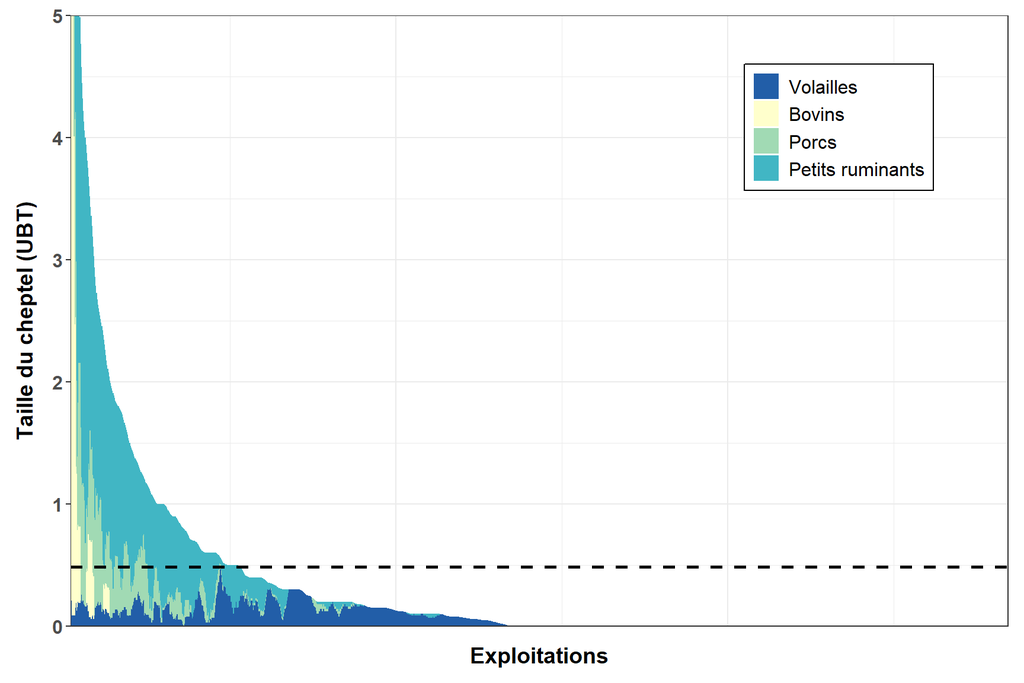

Dynamique du troupeau

| **Variable** | **Overall** N = 1,422 | **Bouenza** N = 191 | **Cuvette** N = 102 | **Cuvette-Ouest** N = 71 | **Kouilou** N = 124 | **Lékoumou** N = 107 | **Likouala** N = 71 | **Niari** N = 255 | **Plateaux** N = 200 | **Pool** N = 243 | **Sangha** N = 58 |
| --- | --- | --- | --- | --- | --- | --- | --- | --- | --- | --- | --- |
| Stock (UBT) | 0.5 (2.4) | 0.5 (2.2) | 0.1 (0.4) | 0.7 (3.5) | 0.2 (0.3) | 0.7 (1.1) | 0.9 (1.9) | 0.5 (1.1) | 0.3 (0.8) | 0.7 (4.6) | 0.2 (1.0) |
| Abattage pour consomation (UBT/an) | 0.0 (0.2) | 0.1 (0.2) | 0.0 (0.0) | 0.1 (0.4) | 0.0 (0.1) | 0.1 (0.1) | 0.1 (0.2) | 0.1 (0.2) | 0.0 (0.1) | 0.1 (0.3) | 0.0 (0.0) |
| Ventes (UBT/an) | 0.1 (0.6) | 0.1 (0.4) | 0.1 (0.4) | 0.1 (0.4) | 0.1 (0.4) | 0.2 (0.3) | 0.1 (0.3) | 0.2 (0.6) | 0.1 (0.2) | 0.1 (1.0) | 0.0 (0.0) |
| Mortalité (UBT/an) | 0.1 (0.4) | 0.0 (0.3) | 0.1 (0.7) | 0.1 (0.2) | 0.0 (0.2) | 0.2 (0.6) | 0.1 (0.3) | 0.1 (0.5) | 0.0 (0.2) | 0.0 (0.2) | 0.1 (0.8) |
| Entrées (naissances et achats, UBT/an | 0.2 (0.7) | 0.2 (0.6) | 0.0 (0.1) | 0.1 (0.5) | 0.1 (0.4) | 0.6 (1.3) | 0.3 (0.8) | 0.3 (0.9) | 0.1 (0.5) | 0.2 (0.7) | 0.1 (0.3) |

# 6. Utilisation de ressources naturelles

Utilisation de ressources naturelles

| **Ressources utilisées** | **Overall** N = 1,422 | **Bouenza** N = 191 | **Cuvette** N = 102 | **Cuvette-Ouest** N = 71 | **Kouilou** N = 124 | **Lékoumou** N = 107 | **Likouala** N = 71 | **Niari** N = 255 | **Plateaux** N = 200 | **Pool** N = 243 | **Sangha** N = 58 |
| --- | --- | --- | --- | --- | --- | --- | --- | --- | --- | --- | --- |
| chasse | 26% | 15% | 42% | 59% | 19% | 38% | 21% | 28% | 28% | 11% | 48% |
| peche | 43% | 34% | 69% | 41% | 35% | 40% | 75% | 55% | 38% | 29% | 43% |
| charbon | 9.0% | 2.1% | 4.9% | 0% | 23% | 9.3% | 0% | 8.6% | 12% | 14% | 1.7% |
| miel | 14% | 12% | 5.9% | 2.8% | 0% | 49% | 17% | 22% | 0% | 15% | 21% |
| fruits | 37% | 29% | 15% | 15% | 9.7% | 48% | 46% | 35% | 65% | 43% | 33% |
| feuilles | 57% | 39% | 50% | 76% | 62% | 74% | 73% | 64% | 64% | 40% | 50% |
| asperges | 40% | 39% | 4.9% | 59% | 0.8% | 69% | 24% | 40% | 54% | 53% | 26% |
| rotins | 0.5% | 0% | 0% | 0% | 0% | 3.7% | 0% | 0.4% | 0.5% | 0.4% | 0% |
| ecorces | 11% | 0.5% | 2.0% | 0% | 3.2% | 34% | 9.9% | 15% | 26% | 1.6% | 19% |
| poivre | 1.1% | 0% | 0% | 0% | 0% | 3.7% | 5.6% | 0.8% | 0% | 0% | 8.6% |
| seve | 9.6% | 3.1% | 11% | 1.4% | 0% | 47% | 1.4% | 9.0% | 3.5% | 15% | 1.7% |
| noix | 26% | 40% | 2.0% | 1.4% | 9.7% | 52% | 0% | 33% | 11% | 43% | 12% |
| chenilles | 22% | 11% | 1.0% | 0% | 1.6% | 50% | 25% | 16% | 32% | 42% | 17% |
| champignons | 43% | 45% | 3.9% | 1.4% | 25% | 64% | 24% | 58% | 49% | 61% | 17% |

# 7. Revenus

Revenus

| **Source de revenus** | **Overall** N = 1,422 | **Bouenza** N = 191 | **Cuvette** N = 102 | **Cuvette-Ouest** N = 71 | **Kouilou** N = 124 | **Lékoumou** N = 107 | **Likouala** N = 71 | **Niari** N = 255 | **Plateaux** N = 200 | **Pool** N = 243 | **Sangha** N = 58 |
| --- | --- | --- | --- | --- | --- | --- | --- | --- | --- | --- | --- |
| Revenus agricoles (XAF/an) | 488,992.2 (974,173.5) | 642,617.8 (1,475,588.4) | 339,225.5 (838,114.8) | 552,950.7 (892,735.1) | 253,911.3 (558,414.0) | 866,864.5 (738,009.7) | 360,042.3 (451,163.2) | 564,388.2 (1,187,265.6) | 345,045.5 (541,373.5) | 397,415.1 (890,371.3) | 672,172.4 (925,790.4) |
| Revenus liés aux ressources naturelles (XAF/an) | 89,389.3 (294,123.1) | 3,874.3 (25,187.0) | 384,069.3 (592,746.1) | 313,119.7 (519,671.0) | 56,016.3 (278,734.7) | 125,604.8 (241,811.4) | 131,985.9 (204,965.2) | 51,485.9 (194,770.3) | 9,375.0 (56,490.5) | 25,962.2 (134,434.3) | 230,862.1 (536,588.6) |
| Revenus autres (XAF/an) | 9,315.6 (144,076.0) | 2,801.0 (21,487.6) | 13,774.5 (66,761.9) | 80,281.7 (595,427.7) | 2,016.1 (22,450.7) | 6,682.2 (58,716.4) | 2,496.0 (8,700.0) | 4,462.7 (49,103.6) | 3,000.0 (42,426.4) | 9,159.7 (91,781.1) | 8,620.7 (65,653.2) |
| Revenus totaux (XAF/an) | 641,122.1 (1,078,016.5) | 682,007.4 (1,486,936.7) | 890,708.6 (1,169,703.9) | 1,104,380.3 (1,253,702.1) | 350,203.3 (807,220.1) | 1,061,076.2 (780,405.6) | 519,383.3 (567,746.6) | 619,253.0 (1,177,324.1) | 443,840.5 (790,911.1) | 468,936.1 (910,861.4) | 987,603.4 (1,057,783.4) |

# 8. Main d’oeuvre

Main d’oeuvre utilisée en agriculture

| **Variables** | **Overall** N = 1,422 | **Bouenza** N = 191 | **Cuvette** N = 102 | **Cuvette-Ouest** N = 71 | **Kouilou** N = 124 | **Lékoumou** N = 107 | **Likouala** N = 71 | **Niari** N = 255 | **Plateaux** N = 200 | **Pool** N = 243 | **Sangha** N = 58 |
| --- | --- | --- | --- | --- | --- | --- | --- | --- | --- | --- | --- |
| Organisation en système d’entraide | 48% | 62% | 40% | 70% | 48% | 45% | 34% | 58% | 40% | 37% | 34% |
| Utilisation de main d’oeuvre extérieure | 76% | 92% | 50% | 72% | 84% | 90% | 76% | 90% | 50% | 77% | 67% |
| Utilisation de main d’oeuve extérieure pour la défriche | 86% | 84% | 63% | 69% | 96% | 100% | 78% | 99% | 73% | 81% | 91% |
| Utilisation de main d’oeuve extérieure pour la préparation du terrain | 80% | 86% | 87% | 90% | 60% | 98% | 78% | 97% | 25% | 89% | 89% |
| Utilisation de main d’oeuve extérieure pour le semis | 63% | 88% | 33% | 20% | 36% | 87% | 34% | 77% | 40% | 77% | 40% |
| Utilisation de main d’oeuve extérieure pour le sarclage | 67% | 79% | 16% | 5.1% | 55% | 98% | 84% | 82% | 41% | 77% | 78% |
| Utilisation de main d’oeuve extérieure pour la récolte | 42% | 63% | 7.5% | 1.7% | 18% | 81% | 43% | 65% | 9.9% | 38% | 29% |
| Utilisation de main d’oeuve extérieure pour le transport | 18% | 21% | 4.5% | 1.7% | 8.8% | 54% | 22% | 25% | 2.3% | 12% | 27% |
| Utilisation de main d’oeuve extérieure pour la transformation | 4.9% | 6.2% | 1.5% | 0% | 5.3% | 0% | 0% | 14% | 2.3% | 1.5% | 0% |

# 9. Dynamique

Dynamique

| **Variables** | **Overall** N = 1,422 | **Bouenza** N = 191 | **Cuvette** N = 102 | **Cuvette-Ouest** N = 71 | **Kouilou** N = 124 | **Lékoumou** N = 107 | **Likouala** N = 71 | **Niari** N = 255 | **Plateaux** N = 200 | **Pool** N = 243 | **Sangha** N = 58 |
| --- | --- | --- | --- | --- | --- | --- | --- | --- | --- | --- | --- |
| Evolution des surfaces cultivées les 10 dernières années |  |  |  |  |  |  |  |  |  |  |  |
| Augmenté | 41% | 43% | 40% | 45% | 53% | 31% | 44% | 51% | 28% | 41% | 26% |
| Réduit | 21% | 28% | 22% | 18% | 8.1% | 31% | 27% | 27% | 7.0% | 20% | 21% |
| Stable | 38% | 29% | 38% | 37% | 39% | 38% | 30% | 22% | 66% | 39% | 53% |
| Project d’agrandir les surfaces cultivées les 5 prochaines années | 73% | 67% | 62% | 52% | 70% | 54% | 96% | 76% | 90% | 70% | 97% |
| Pensez-vous que votre exploitation sera reprise? |  |  |  |  |  |  |  |  |  |  |  |
| Ne sais pas | 38% | 41% | 23% | 20% | 44% | 34% | 49% | 31% | 66% | 26% | 53% |
| Non | 16% | 12% | 40% | 34% | 20% | 2.8% | 8.5% | 13% | 6.0% | 22% | 12% |
| Oui | 46% | 47% | 37% | 46% | 35% | 64% | 42% | 56% | 28% | 52% | 34% |

# 10. Equipements agricoles et de transport

Equipements utilisés

| **Equipement** | **Overall** N = 1,422 | **Bouenza** N = 191 | **Cuvette** N = 102 | **Cuvette-Ouest** N = 71 | **Kouilou** N = 124 | **Lékoumou** N = 107 | **Likouala** N = 71 | **Niari** N = 255 | **Plateaux** N = 200 | **Pool** N = 243 | **Sangha** N = 58 |
| --- | --- | --- | --- | --- | --- | --- | --- | --- | --- | --- | --- |
| Tracteur | 13% | 35% | 0% | 2.8% | 0.8% | 0% | 1.4% | 2.7% | 26% | 22% | 1.7% |
| Motoculteur | 0.2% | 1.6% | 0% | 0% | 0% | 0% | 0% | 0% | 0% | 0% | 0% |
| Charrue | 2.0% | 1.0% | 0% | 0% | 0% | 0% | 0% | 0% | 5.0% | 6.6% | 0% |
| Herse | 1.1% | 0.5% | 0% | 0% | 1.6% | 0% | 0% | 0% | 0% | 4.9% | 0% |
| Butteuse | <0.1% | 0% | 0% | 0% | 0% | 0% | 0% | 0% | 0% | 0.4% | 0% |
| Motopompe | 1.3% | 1.6% | 2.0% | 1.4% | 0.8% | 0% | 0% | 3.5% | 0% | 0.8% | 0% |
| Tronçonneuse | 12% | 1.6% | 5.9% | 13% | 27% | 36% | 4.2% | 20% | 0% | 2.9% | 29% |
| Pulverisateur | 2.7% | 3.7% | 0% | 1.4% | 0% | 0% | 8.5% | 3.5% | 2.5% | 4.1% | 0% |
| Voiture | 67% | 78% | 45% | 58% | 70% | 66% | 2.8% | 75% | 80% | 84% | 1.7% |
| Kavaki | 13% | 32% | 8.8% | 2.8% | 4.8% | 9.3% | 30% | 17% | 1.5% | 1.6% | 33% |
| Moto | 40% | 41% | 60% | 76% | 7.3% | 75% | 21% | 35% | 57% | 25% | 12% |
| Brouette | 9.3% | 5.8% | 31% | 21% | 0.8% | 0.9% | 13% | 2.4% | 18% | 7.0% | 8.6% |
| Vélo | 0.6% | 0% | 1.0% | 0% | 0% | 1.9% | 1.4% | 0% | 2.0% | 0% | 1.7% |

Equipements en propriété

| **Equipement** | **Overall** N = 1,422 | **Bouenza** N = 191 | **Cuvette** N = 102 | **Cuvette-Ouest** N = 71 | **Kouilou** N = 124 | **Lékoumou** N = 107 | **Likouala** N = 71 | **Niari** N = 255 | **Plateaux** N = 200 | **Pool** N = 243 | **Sangha** N = 58 |
| --- | --- | --- | --- | --- | --- | --- | --- | --- | --- | --- | --- |
| Tracteur | 0.3% | 0% | 0% | 0% | 0.8% | 0% | 0% | 0.4% | 0% | 0.8% | 0% |
| Motopompe | 0.8% | 1.0% | 0% | 0% | 0% | 0% | 0% | 2.7% | 0.5% | 0.4% | 0% |
| Batteuse | <0.1% | 0% | 0% | 0% | 0% | 0% | 0% | 0% | 0.5% | 0% | 0% |
| Tronçonneuse | 1.1% | 0.5% | 2.0% | 1.4% | 2.4% | 2.8% | 0% | 1.6% | 0% | 0.4% | 1.7% |
| Pulverisateur | 12% | 28% | 0% | 1.4% | 31% | 0% | 8.5% | 13% | 16% | 4.5% | 0% |
| Voiture | 0.3% | 0% | 0% | 0% | 0.8% | 0% | 0% | 0% | 0% | 1.2% | 0% |
| Kavaki | 1.1% | 1.6% | 2.0% | 0% | 0% | 2.8% | 4.2% | 0.4% | 0% | 0% | 5.2% |
| Moto | 9.4% | 12% | 12% | 13% | 0.8% | 5.6% | 8.5% | 13% | 14% | 5.3% | 6.9% |
| Brouette | 7.7% | 4.7% | 25% | 15% | 0% | 0.9% | 8.5% | 1.6% | 18% | 5.8% | 6.9% |
| Vélo | 0.5% | 0.5% | 1.0% | 0% | 0% | 0% | 1.4% | 0% | 2.0% | 0% | 0% |

# 11. Environnement socio-economique

Groupements

| **Variables** | **Overall** N = 1,422 | **Bouenza** N = 191 | **Cuvette** N = 102 | **Cuvette-Ouest** N = 71 | **Kouilou** N = 124 | **Lékoumou** N = 107 | **Likouala** N = 71 | **Niari** N = 255 | **Plateaux** N = 200 | **Pool** N = 243 | **Sangha** N = 58 |
| --- | --- | --- | --- | --- | --- | --- | --- | --- | --- | --- | --- |
| Membre d’un groupement | 19% | 25% | 12% | 20% | 12% | 37% | 5.6% | 24% | 16% | 19% | 6.9% |
| Groupement avec agrément |  |  |  |  |  |  |  |  |  |  |  |
| Non | 50% | 38% | 67% | 79% | 80% | 53% | 25% | 71% | 32% | 23% | 50% |
| Oui | 50% | 63% | 33% | 21% | 20% | 48% | 75% | 29% | 68% | 77% | 50% |
| Nature du groupement |  |  |  |  |  |  |  |  |  |  |  |
| Groupement feminin | 11% | 8.3% | 58% | 14% | 20% | 5.0% | 0% | 16% | 3.2% | 2.1% | 0% |
| Groupement masculin | 3.6% | 6.3% | 0% | 0% | 6.7% | 0% | 0% | 4.8% | 0% | 4.3% | 25% |
| Groupement mixte (Homme/Femme) | 85% | 85% | 42% | 86% | 73% | 95% | 100% | 77% | 97% | 94% | 50% |
| Ménage agricole | 0.7% | 0% | 0% | 0% | 0% | 0% | 0% | 1.6% | 0% | 0% | 25% |
| Objectif: accès aux intrants et petits équipements | 5.4% | 2.1% | 0% | 0% | 0% | 20% | 0% | 1.6% | 6.5% | 6.4% | 0% |
| Objectif: accès à la mécanisation | 1.4% | 0% | 0% | 7.1% | 0% | 0% | 0% | 1.6% | 3.2% | 2.1% | 0% |
| Objectif: entraide | 47% | 54% | 17% | 36% | 87% | 48% | 0% | 55% | 0% | 64% | 0% |
| Objectif: formation et partage des savoirs | 4.7% | 4.2% | 0% | 21% | 13% | 13% | 0% | 1.6% | 0% | 0% | 0% |
| Objectif: transformation | 2.9% | 4.2% | 17% | 0% | 0% | 0% | 0% | 3.2% | 0% | 4.3% | 0% |
| Objectif: commercialisation | 12% | 19% | 8.3% | 0% | 0% | 25% | 0% | 9.7% | 19% | 4.3% | 0% |
| Objectif: bénéficier d’aides de projets | 16% | 4.2% | 0% | 21% | 20% | 50% | 0% | 16% | 9.7% | 8.5% | 0% |
| Objectif: production agricole | 85% | 88% | 92% | 86% | 40% | 100% | 100% | 77% | 94% | 83% | 100% |
| Objectif: transport | 0.4% | 2.1% | 0% | 0% | 0% | 0% | 0% | 0% | 0% | 0% | 0% |

Contrats

| **Variables** | **Overall** N = 1,422 | **Bouenza** N = 191 | **Cuvette** N = 102 | **Cuvette-Ouest** N = 71 | **Kouilou** N = 124 | **Lékoumou** N = 107 | **Likouala** N = 71 | **Niari** N = 255 | **Plateaux** N = 200 | **Pool** N = 243 | **Sangha** N = 58 |
| --- | --- | --- | --- | --- | --- | --- | --- | --- | --- | --- | --- |
| Contrat avec acheteurs? | 11% | 7.9% | 13% | 18% | 9.7% | 17% | 13% | 7.8% | 8.0% | 13% | 10% |
| Contrat sur maïs | 14% | 13% | 23% | 7.7% | 8.3% | 17% | 44% | 10% | 0% | 13% | 17% |
| Contrat sur arachide | 14% | 33% | 0% | 0% | 17% | 17% | 33% | 25% | 0% | 9.4% | 17% |
| Contrat sur cacao | 3.2% | 0% | 0% | 0% | 0% | 0% | 22% | 0% | 0% | 0% | 50% |
| Contrat sur safou | 11% | 13% | 23% | 15% | 0% | 5.6% | 0% | 25% | 0% | 9.4% | 17% |
| Contrat sur plantain | 11% | 13% | 0% | 15% | 8.3% | 22% | 0% | 35% | 6.3% | 0% | 0% |
| Contrat sur palmier | 1.3% | 0% | 0% | 7.7% | 0% | 0% | 0% | 0% | 0% | 3.1% | 0% |
| Contrat sur cultures maraichères | 9.7% | 6.7% | 15% | 0% | 8.3% | 5.6% | 0% | 15% | 0% | 22% | 0% |
| Contrat sur autres annuelles (e.g., sesame) | 1.3% | 0% | 0% | 0% | 0% | 0% | 0% | 0% | 0% | 6.3% | 0% |
| Contrat sur autres turbercules | 3.2% | 6.7% | 0% | 15% | 0% | 0% | 0% | 5.0% | 6.3% | 0% | 0% |
| Contrat sur autres fruitriers | 1.3% | 0% | 0% | 0% | 0% | 0% | 0% | 10% | 0% | 0% | 0% |
| Contrat sur viande d’élevage | 1.9% | 0% | 7.7% | 0% | 0% | 0% | 0% | 5.0% | 0% | 3.1% | 0% |
| Contrat sur viande de brousse | 2.6% | 0% | 0% | 7.7% | 8.3% | 0% | 0% | 10% | 0% | 0% | 0% |
| Contrat sur poisson | 2.6% | 0% | 0% | 0% | 0% | 0% | 0% | 5.0% | 6.3% | 6.3% | 0% |
| Contrat sur produits de la forêt | 2.6% | 0% | 7.7% | 7.7% | 8.3% | 0% | 0% | 5.0% | 0% | 0% | 0% |
| Contrat sur manioc | 69% | 93% | 62% | 85% | 67% | 100% | 0% | 55% | 75% | 75% | 0% |
| Contrat sur banane | 6.5% | 6.7% | 0% | 7.7% | 8.3% | 5.6% | 0% | 20% | 6.3% | 3.1% | 0% |
| Contrat sur pois d’angole | 0.6% | 6.7% | 0% | 0% | 0% | 0% | 0% | 0% | 0% | 0% | 0% |
| Contrat sur pastèque | 0.6% | 0% | 0% | 0% | 0% | 0% | 0% | 0% | 0% | 3.1% | 0% |
| Contrat sur ananas | 5.8% | 0% | 7.7% | 15% | 33% | 5.6% | 0% | 0% | 0% | 3.1% | 0% |
| Nature du contrat |  |  |  |  |  |  |  |  |  |  |  |
| Contrat formel (écrit et reconnu) | 1.9% | 6.7% | 0% | 0% | 0% | 11% | 0% | 0% | 0% | 0% | 0% |
| Contrat informel (oral, non-contraignant) | 98% | 93% | 100% | 100% | 100% | 89% | 100% | 100% | 100% | 100% | 100% |
| Accord sur le prix | 71% | 80% | 77% | 23% | 83% | 50% | 100% | 55% | 100% | 72% | 100% |
| Accord sur la quantité | 54% | 93% | 23% | 77% | 42% | 39% | 0% | 80% | 38% | 69% | 0% |
| Accord sur la qualité | 36% | 47% | 15% | 23% | 58% | 5.6% | 0% | 75% | 31% | 47% | 0% |
| Accord sur la fourniture d’intrants | 1.9% | 13% | 0% | 0% | 0% | 0% | 0% | 0% | 0% | 3.1% | 0% |
| Accord sur l’itinéraire technique | 0.6% | 0% | 0% | 0% | 0% | 0% | 0% | 5.0% | 0% | 0% | 0% |
| Accord sur le délai de paiement | 9.7% | 6.7% | 15% | 54% | 17% | 0% | 0% | 5.0% | 0% | 6.3% | 0% |
| Accord sur crédit | 5.8% | 6.7% | 23% | 23% | 0% | 0% | 0% | 5.0% | 0% | 3.1% | 0% |

Marchés

| **Variables** | **Overall** N = 1,422 | **Bouenza** N = 191 | **Cuvette** N = 102 | **Cuvette-Ouest** N = 71 | **Kouilou** N = 124 | **Lékoumou** N = 107 | **Likouala** N = 71 | **Niari** N = 255 | **Plateaux** N = 200 | **Pool** N = 243 | **Sangha** N = 58 |
| --- | --- | --- | --- | --- | --- | --- | --- | --- | --- | --- | --- |
| Vente au village | 71% | 66% | 86% | 83% | 69% | 98% | 86% | 82% | 54% | 45% | 97% |
| Vente au goudron | 11% | 11% | 9.8% | 0% | 4.8% | 0% | 8.5% | 18% | 16% | 12% | 10% |
| Vente au chef lieu | 29% | 40% | 68% | 58% | 2.4% | 41% | 25% | 37% | 12% | 7.6% | 28% |
| Vente à Brazzaville ou Pointe-Noire | 42% | 59% | 2.9% | 2.8% | 66% | 52% | 1.4% | 26% | 43% | 82% | 0% |
| Pas de vente | 1.2% | 1.0% | 0% | 0% | 3.2% | 0.9% | 1.4% | 1.2% | 1.0% | 1.5% | 0% |
| Distance (km) point de vente préférentiel | 666.8 (13,046.2) | 93.0 (132.4) | 24.2 (21.5) | 32.6 (129.1) | 70.5 (43.3) | 233.5 (203.4) | 16.6 (17.6) | 44.9 (78.8) | 3,344.3 (30,679.4) | 106.1 (70.0) | 8.1 (7.9) |
| Pertes de production liées au transport |  |  |  |  |  |  |  |  |  |  |  |
| Non | 59% | 75% | 64% | 63% | 63% | 29% | 36% | 63% | 70% | 45% | 46% |
| Oui | 41% | 25% | 36% | 37% | 37% | 71% | 64% | 37% | 30% | 55% | 54% |